# IODS course project

Let’s check now the summary data by Group and ID, having mean as the summary variable.

```r
RATSL_my8S <- RATSL_my %>%
  filter(Time > 0) %>%
  group_by(Group, ID) %>%
  summarise( mean=mean(Weight) ) %>%
  ungroup()
glimpse(RATSL_my8S)
```

```
## Rows: 16
## Columns: 3
## $ Group <fct> 1, 1, 1, 1, 1, 1, 1, 1, 2, 2, 2, 2, 3, 3, 3, 3
## $ ID    <fct> 1, 2, 3, 4, 5, 6, 7, 8, 9, 10, 11, 12, 13, 14, 15, 16
## $ mean  <dbl> 261.0909, 237.6364, 260.1818, 266.5455, 269.4545, 274.7273, 2...
```

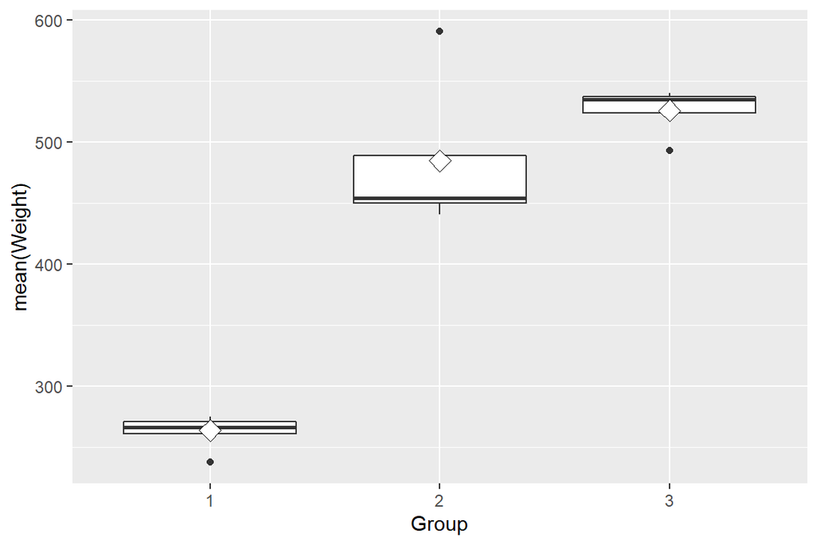

```r
p3 <- ggplot(RATSL_my8S, aes(x = Group, y = mean)) +
  geom_boxplot() +
  stat_summary(fun = "mean", geom = "point", shape=23, size=4, fill = "white") +
  scale_y_continuous(name = "mean(Weight)")
print(p3)
```

The plot suggests the presence of 3 possible “outliers” given that their weight values are well beyond the confidence interval.

I will create than a new data by filtering the outliers and draw the plot again.

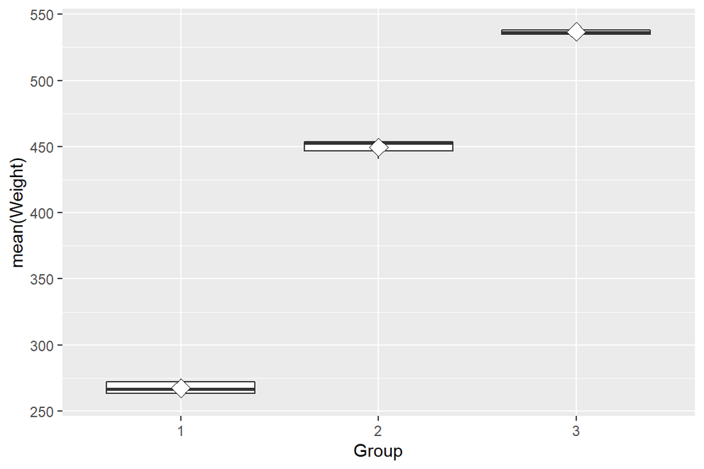

```r
RATSL_my8S1 <- RATSL_my8S %>%
  filter( ID!=2 & ID!= 12 & ID!= 13)
p4 <- ggplot(RATSL_my8S1, aes(x = Group, y = mean)) +
  geom_boxplot() +
  stat_summary(fun = "mean", geom = "point", shape=23, size=4, fill = "white") +
  scale_y_continuous(name = "mean(Weight)")
print(p4)
```

As a consequence of removing the outliers the confidence intervals are tighter around the mean, confirming that the outliers were distorting the distribution of the data.

To assess any difference between the three groups, I will apply a t-test and calculate a confidence interval for the differences. I will use the data without the outliers.

First, only groups 2 and 3:

```r
a <- filter(RATSL_my8S1, Group != 1)
t.test(mean ~ Group, data = a, var.equal = TRUE)
```

```
##
##  Two Sample t-test
##
## data:  mean by Group
## t = -18.428, df = 4, p-value = 5.102e-05
## alternative hypothesis: true difference in means is not equal to 0
## 95 percent confidence interval:
##  -100.45660  -74.14946
## sample estimates:
## mean in group 2 mean in group 3
##        449.4545        536.7576
```

Now groups 1 and 3, and 1 and 2

```r
b <- filter(RATSL_my8S1, Group != 2)
t.test(mean ~ Group, data = b, var.equal = TRUE)
```

```
##
##  Two Sample t-test
##
## data:  mean by Group
## t = -73.22, df = 8, p-value = 1.348e-12
## alternative hypothesis: true difference in means is not equal to 0
## 95 percent confidence interval:
##  -277.7979 -260.8342
## sample estimates:
## mean in group 1 mean in group 3
##        267.4416        536.7576
```

```r
c <- filter(RATSL_my8S1, Group != 3) # Only groups 1 and 2
t.test(mean ~ Group, data = c, var.equal = TRUE)
```

```
##
##  Two Sample t-test
##
## data:  mean by Group
## t = -41.656, df = 8, p-value = 1.215e-10
## alternative hypothesis: true difference in means is not equal to 0
## 95 percent confidence interval:
##  -192.089 -171.937
## sample estimates:
## mean in group 1 mean in group 2
##        267.4416        449.4545
```

```r
RATS <- read.table("https://raw.githubusercontent.com/KimmoVehkalahti/MABS/master/Examples/data/rats.txt", header = TRUE, sep = '\t')
str(RATS)
```

```
## 'data.frame':    16 obs. of  13 variables:
##  $ ID   : int  1 2 3 4 5 6 7 8 9 10 ...
##  $ Group: int  1 1 1 1 1 1 1 1 2 2 ...
##  $ WD1  : int  240 225 245 260 255 260 275 245 410 405 ...
##  $ WD8  : int  250 230 250 255 260 265 275 255 415 420 ...
##  $ WD15 : int  255 230 250 255 255 270 260 260 425 430 ...
##  $ WD22 : int  260 232 255 265 270 275 270 268 428 440 ...
##  $ WD29 : int  262 240 262 265 270 275 273 270 438 448 ...
##  $ WD36 : int  258 240 265 268 273 277 274 265 443 460 ...
##  $ WD43 : int  266 243 267 270 274 278 276 265 442 458 ...
##  $ WD44 : int  266 244 267 272 273 278 271 267 446 464 ...
##  $ WD50 : int  265 238 264 274 276 284 282 273 456 475 ...
##  $ WD57 : int  272 247 268 273 278 279 281 274 468 484 ...
##  $ WD64 : int  278 245 269 275 280 281 284 278 478 496 ...
```

```r
RATSL_my8S2 <- RATSL_my8S %>%
  mutate(baseline = RATS$WD1)
fit <- lm(baseline ~ mean, data = RATSL_my8S2)
anova(fit)
```

```
## Analysis of Variance Table
##
## Response: baseline
##           Df Sum Sq Mean Sq F value   Pr(>F)
## mean       1 235420  235420  1698.1 5.14e-16 ***
## Residuals 14   1941     139
## ---
## Signif. codes:  0 '***' 0.001 '**' 0.01 '*' 0.05 '.' 0.1 ' ' 1
```